# *Lectura 2: Ideas sobre estadística*

## **Fundamentos de estadística para analítica de Datos.**

### *Docente: Luis Andres Campos Maldonado.*

## *¿Que es la estadística?*

La estadística es una disciplina científica que se ocupa de la obtención, orden y análisis de un conjunto de datos con el fin de obtener explicaciones y predicciones sobre fenómenos observados. En esta tarea se busca sistematizar, recoger, ordenar y presentar datos referentes a un fenomeno que presenta variabilidad o incertidumbre para su estudio metódico. Esto busca poder lograr hacer previsiones, tomar decisiones y obtener conclusiones.

## *Población y muestra*

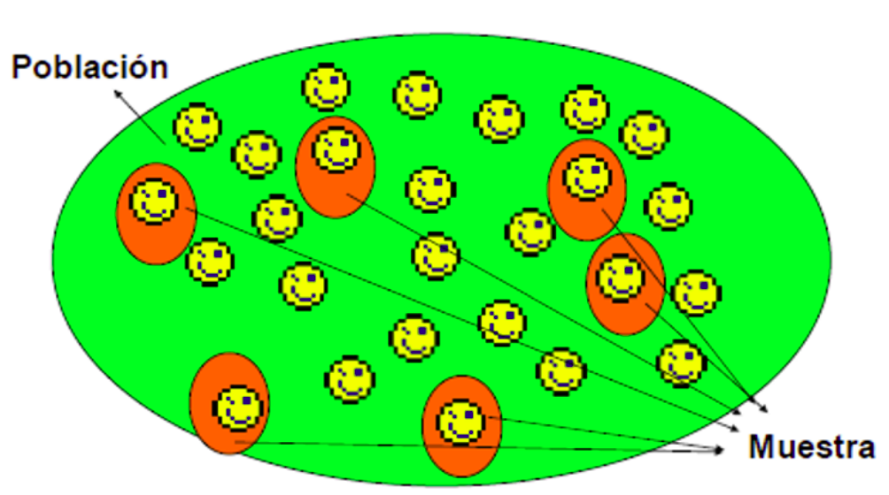

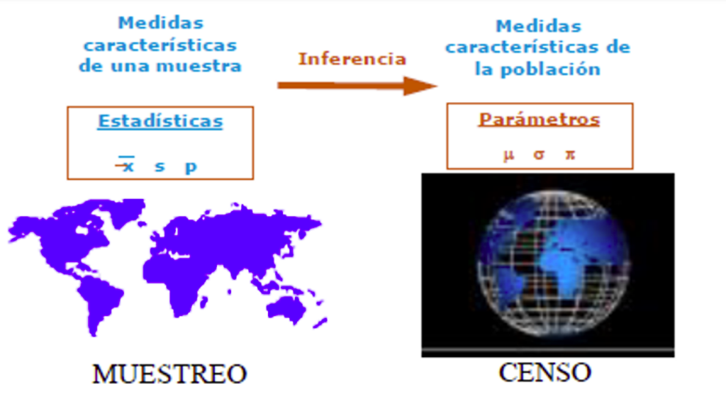

Consideremos algunos términos que serán de uso recurrente.

*Población*

Es el conjunto de todos los elementos o unidades (personas, objetos, animales, etc.) bajo consideración en un estudio estadístico y sobre los que se desea medir una o varias características, con el fin de describir y/o hacer inferencia de las mismas.

*Marco muestral*

Es el medio por el cual los elementos de una población objetivo son identificados.

*Muestra*

Es un subconjunto de elementos o unidades de una población estadística seleccionados de forma adecuada (mediante algún esquema de muestreo).

*Unidad de muestreo*

Es la unidad que es de hecho seleccionada para componer la muestra.

*Variable de interés*

Es la característica propia de los individuos sobre la que se realiza la inferencia para resolver los objetivos de la investigación.

#### *Ejemplo.*

Supongamos que el sistema de gestión integral de Transmilenio desea evaluar la proporción de empleados que están a favor de una nueva política de bonificación salarial de la empresa.

Analicemos las definiciones dadas previamente respecto al problema en cuestión:

*Población* Está conformada por todos y cada uno de los empleados de Transmilenio que se puedan ser “medidos” mediante una encuesta de opinión.

*Unidad de muestreo:* Todos los empleados de Trasmilenio o ́areas funcionales.

*Marco muestral:* si se especifica como unidad de muestreo el votante individual, el marco muestral será una lista de todos los empleados de Transmilenio. Si se consideran las ́areas funcionales como unidades de muestreo, tendremos más de un marco muestral y serán las listas de empleados por departamento.

*Muestra:* será una colección de unidades de muestreo (empleados de Transmilenio) obtenidas a partir de uno o varios marcos de muestreo.

El muestreo es el área de la estadística que estudia técnicas y procedimientos para retirar y analizar una muestra con el objetivo de hacer inferencia respecto a una población.

¿Cuál es la importancia del muestreo?

1. Poder cuantificar una población.
2. Caracterizar una población mediante una muestra.
3. Poder tomar decisiones basados en una muestra probabilística.

*Ejemplo de aplicaciones:*

- **Marketing:** Encuestas de mercado, encuestas de satisfacci ́on del cliente.
- **Sociología:** Encuestas de opinión.
- **Ciencia Política:** Encuestas electorales.
- **Psicología:** Investigaciones comportamiento, investigaciones de calidad de vida.
- **Ingeniería:** Implementación de planes para seguimiento de calidad, control de calidad.

*Ventajas del muestreo vs Censo:*

- Bajo costo.
- Rapidez.
- Calidad de la información.

### *Tipos de datos:*

Una **variable** es cualquier característica cuyo valor puede cambiar de un objeto a otro en la población.

Por su naturaleza podemos considerar variables del tipo:

- Univariantes: Son quellas que en nn conjunto de datos univariantes se compone de observaciones realizadas en una sola variable.
- Bivariantes: Se tienen datos bivariantes cuando se realizan observaciones en cada unidad experimental de dos variables.
- Multivariantes: Estos surgen cuando se realizan observaciones en más de una variable (por lo que bivariante es un caso especial de multivariante).

Vamos a considerar los 2 tipos de datos clásicos:

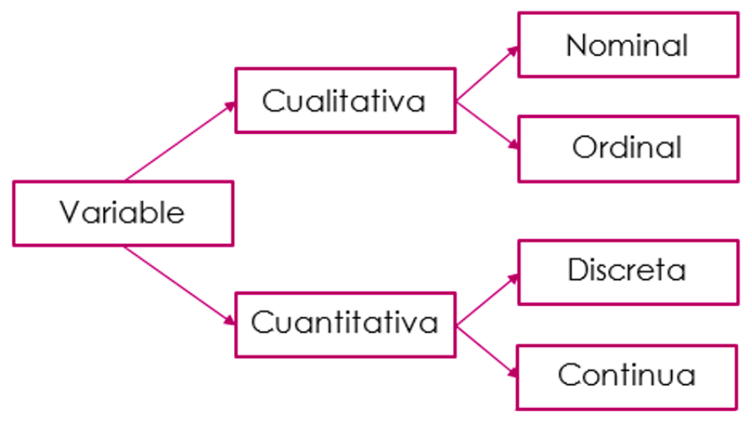

- *Numéricos:* Datos que se expresan en una escala numérica.
1. Continuo: Datos que pueden tomar cualquier valor en un intervalo.
2. Discreto: Datos que solo pueden tomar valores enteros, como conteos.
- *Categóricos:* Datos que pueden tomar solo un conjunto específico y finito de valores que representan un conjunto de posibles categorías.
1. Binario: Un caso especial de datos categóricos con solo dos categorías de valores, por ejemplo, 0/1, verdadero Falso. (Sinónimos: dicotómico, lógico, indicador, booleano)
2. Ordinal: Datos categóricos que tienen un ordenamiento explícito. (Sinónimo: factor ordenado)

De esta clasificación dependerá su tratamiento pues estos datos normalmente se clasifican en el software por sus tipos, los cuales incluyen: continuos, discretos, binarios y ordinales. Así, la tipificación de datos en el software actúa como una señal para el software sobre cómo procesar la información.

### *`DataFrame`*

El tratamiento de información comunmente se hace con datos rectagulares (Hoja de cálculo) pues son la estructura de datos básica para fines estadísticos y modelos de machine learning. Esta tipo de información la vamos a llamar de acá en adelante `dataframe`.

Una columna dentro de un dataframe se conoce comúnmente como una característica (feature). No tan común en este ambito, pero términos usados como: atributo, entrada, predictor.

Muchos proyectos en ciencia de datos implican predecir un resultado, a menudo un resultado de sí/no. Las features son las utilizadas para predecir el resultado de un experimento o un estudio. Esta variable es conocida como `target` o variable dependiente o variable respuesta.

Una fila dentro de un dataframe se conoce comúnmente como un `record`. O quizá como: instancia u observación.

Importemos nuestro módulo de trabajo y un dataframe.

```r
rm(list = ls())
library(DT)
library(readr)
url_base= 'https://raw.githubusercontent.com/lacamposm/Fundamentos_Analitica/main/data/'
name_data <- 'TABLA_PERSONAS.csv'
url_data <- paste(url_base, name_data, sep = "")
df <- read_delim(url_data, delim = ";")
df <- df[-c(1)]
datatable(df)
```

|  | EDAD | SEXO | ESTATURA | NIVEL_ESCOLAR | MARCA_DE_AUTO | NUMERO_DE_HIJOS | SALARIO |
| --- | --- | --- | --- | --- | --- | --- | --- |
| 1 | 21 | M | 154 | MAESTRIA | AUDI | 0 | 1200000 |
| 2 | 26 | F | 155 | PROFESIONAL | RENAULT | 5 | 1250000 |
| 3 | 30 | F | 16 | DOCTORADO | BMW | 2 | 900000 |
| 4 | 31 | F | 17 | PROFESIONAL | RENAULT | 2 | 800000 |
| 5 | 35 | M | 171 | MAESTRIA | AUDI | 1 | 950000 |
| 6 | 65 | M | 18 | MAESTRIA | AUDI | 1 | 2000000 |
| 7 | 45 | M | 154 | MAESTRIA | BMW | 1 | 2500000 |
| 8 | 42 | F | 152 | PROFESIONAL | RENAULT | 1 | 3500000 |
| 9 | 52 | F | 151 | DOCTORADO | RENAULT | 0 | 4700000 |
| 10 | 63 | M | 165 | DOCTORADO | RENAULT | 0 | 5000000 |

[output cut: 21 more lines]

```r
## Estructura de datos importados
print(dim(df))
```

```
## [1] 31  7
```

```r
str(df)
```

```
## tibble [31 × 7] (S3: tbl_df/tbl/data.frame)
##  $ EDAD           : num [1:31] 21 26 30 31 35 65 45 42 52 63 ...
##  $ SEXO           : chr [1:31] "M" "F" "F" "F" ...
##  $ ESTATURA       : num [1:31] 154 155 16 17 171 18 154 152 151 165 ...
##  $ NIVEL_ESCOLAR  : chr [1:31] "MAESTRIA" "PROFESIONAL" "DOCTORADO" "PROFESIONAL" ...
##  $ MARCA_DE_AUTO  : chr [1:31] "AUDI" "RENAULT" "BMW" "RENAULT" ...
##  $ NUMERO_DE_HIJOS: num [1:31] 0 5 2 2 1 1 1 1 0 0 ...
##  $ SALARIO        : num [1:31] 1200000 1250000 900000 800000 950000 2000000 2500000 3500000 4700000 5000000 ...
```

```r
apply(is.na(df), 2, sum)
```

```
##            EDAD            SEXO        ESTATURA   NIVEL_ESCOLAR   MARCA_DE_AUTO
##               0               1               0               1               0
## NUMERO_DE_HIJOS         SALARIO
##               0               0
```

```r
## Registro con NaN.
datatable(df[is.na(df$SEXO), ])
```

|  | EDAD | SEXO | ESTATURA | NIVEL_ESCOLAR | MARCA_DE_AUTO | NUMERO_DE_HIJOS | SALARIO |
| --- | --- | --- | --- | --- | --- | --- | --- |
| 1 | 34 |  | 15 |  | AUDI | 0 | 0 |

### *Tabla de frecuencias.*

[output not shown]

Algunas consideraciones de esta tabla.

- La **frecuencia absoluta** $(n_i)$ de una clase $X_i$ es el número de veces que se repite la clase $X_i$.
- La suma de todas las frecuencias absolutas $(n_i)$ con $i = 1,2,3,\dots , k$ es igual al número total de datos (elementos).

$$\sum
\limits_{i=1} ^{k} n_i = n_1 + n_2
+ \dots + n_k = N$$

donde $N$ es el número total de elementos.

- La **frecuencia relativa** $f_i$ de una clase $X_i$ es la proporción de valores iguales a $X_i$ en el conjunto de datos. En otras palabras

$$f_i=
\dfrac{n_i}{N}$$
donde $n_i$ representa el número de veces que se repite $X_i$

Vamos a construir una tabla de frecuencias de la feature `MARCA_DE_AUTO`

```r
library(dplyr)
frec <- table(df$MARCA_DE_AUTO)
table_frec <- data.frame(cbind(frec))
table_frec <- table_frec %>% mutate(frec_rela=frec/sum(frec), frec_porcent = 100*frec/sum(frec)) %>% arrange(desc(frec)) %>% mutate(across(everything(), round, 2))
datatable(table_frec)
```

|  | frec | frec_rela | frec_porcent |
| --- | --- | --- | --- |
| AUDI | 8 | 0.26 | 25.81 |
| BMW | 6 | 0.19 | 19.35 |
| CHEVROLET | 6 | 0.19 | 19.35 |
| RENAULT | 6 | 0.19 | 19.35 |
| FORD | 5 | 0.16 | 16.13 |

### *Representación gráfica : barras y tortas.*

#### *Gráfico de barras de la frecuencia absoluta.*

Haremos algunas indicaciones sobre gráficos de barras:

```r
datatable(table_frec["frec"])
```

|  | frec |
| --- | --- |
| AUDI | 8 |
| BMW | 6 |
| CHEVROLET | 6 |
| RENAULT | 6 |
| FORD | 5 |

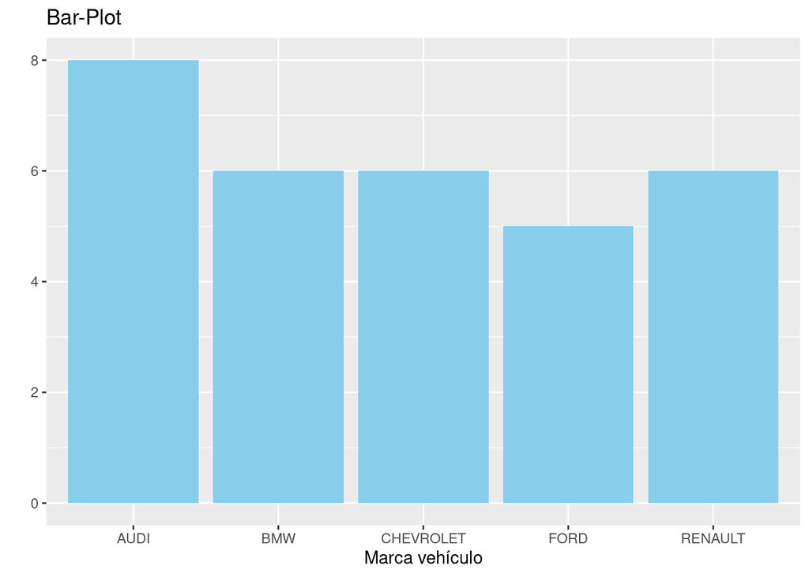

```r
## Módulo para plots.
library(ggplot2)
ggplot(df) +
  aes(x = MARCA_DE_AUTO) +
  geom_bar(fill="skyblue") +
  labs(x = "Marca vehículo", y = "", title = "Bar-Plot")
```

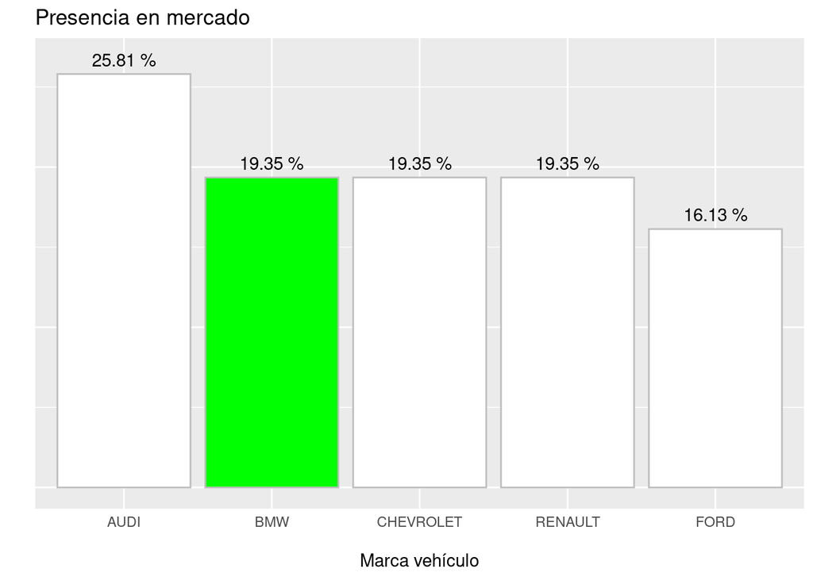

```r
temp <- table_frec
temp['MARCA'] <- rownames(temp)
temp$MARCA <- factor(temp$MARCA, levels = temp$MARCA[order(temp$frec, decreasing = TRUE)])
##
ggplot(temp) +
  aes(MARCA, frec_porcent) +
  geom_bar(stat = "identity", fill = c("white", "green", "white", "white", "white"),
           color = "grey") +
  labs(x = "\nMarca vehículo", y = "", title = "Presencia en mercado") +
  annotate("text", x = 1:5, y = table_frec$frec_porcent + 0.9, label = paste(temp$frec_porcent,"%"))+
  theme(axis.text.y = element_blank(), axis.ticks = element_blank())
```

#### *Ejercicio 1.*

Realice un plot como el anterior sobre la feature `NIVEL_ESCOLAR`. Las barras se deben presentar de la menor a la mayor

*Respuesta.*

### *2. Gráfico de torta de la frecuencia absoluta.*

También podemos representar y resumir las variables con un pie o diagrama de torta. Recordemos que estos diagramas se representan con un círculo, en el cual, las proporciones de cada una de las categorías de la variable satisfacen que a mayor área (o pedazo de círculo) indica una mayor proporción de la categoría con respecto al total. Adicionalmente, no es recomendable usar estos diagramas si se tienen muchas categorías para facilitar su lectura.

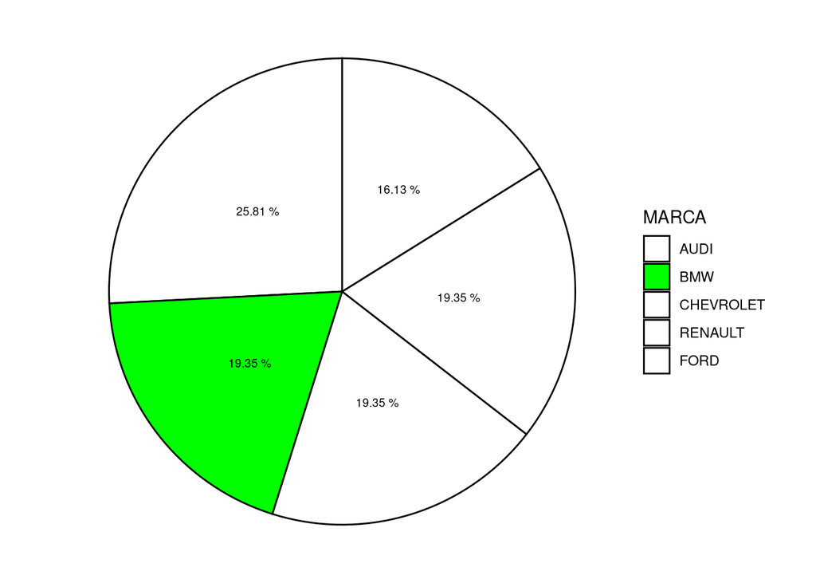

```r
ggplot(temp) %>% +
  aes(x="", y = frec_porcent, fill = MARCA) +
  geom_col(color = "black") +
  geom_text(aes(label = paste(frec_porcent, "%")),
            position = position_stack(vjust = 0.5),
            size = 2.5) +
  coord_polar(theta = "y") +
  scale_fill_manual(values = c("white", "green", "white", "white", "white")) +
  theme_void()
```

### *3. Gráfico de barras horizontal.*

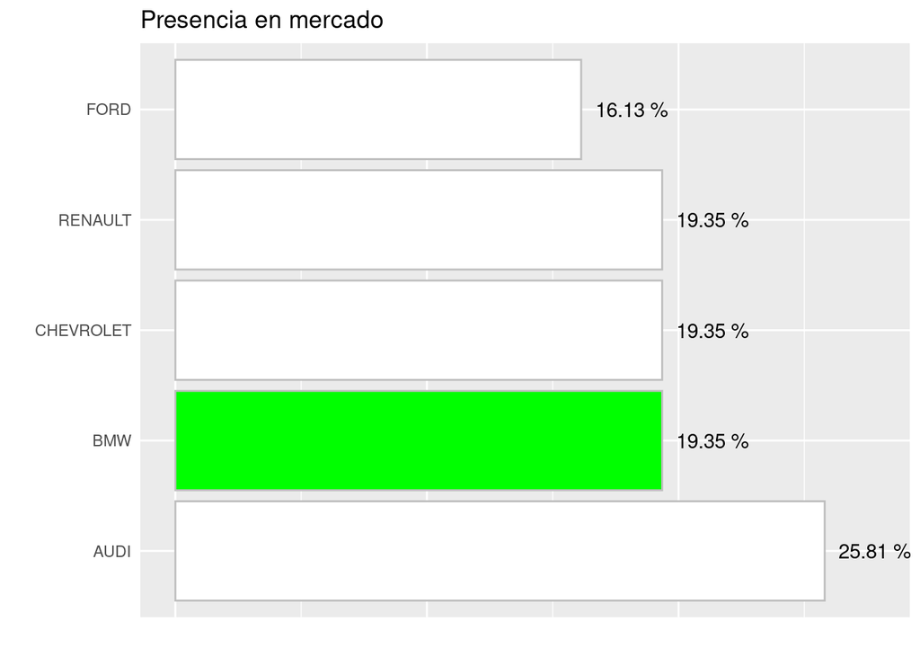

```r
ggplot(temp) %>% +
  aes(x = frec_porcent, y = MARCA) +
  geom_bar(stat = "identity", fill = c("white", "green", "white", "white", "white"), color = "grey") +
  labs(x = "", y = "", title = "Presencia en mercado") +
  annotate("text", y = 1:5, x = table_frec$frec_porcent + 2, label = paste(temp$frec_porcent,"%"))+
  theme(axis.text.x = element_blank(), axis.ticks = element_blank())
```

### *4. Gráficos de barras múltiples.*

Para hacer varios gráficos de barras vamos a importar la información en el archivo *NOTASBARRAS.xlsx*.

```r
#install.packages("rio")
library(rio)
library(readxl)
df1 <- rio::import('https://raw.githubusercontent.com/lacamposm/Fundamentos_Analitica/main/data/NOTASBARRAS.xlsx')
colnames(df1) <-c('Carrera', 'PromN1', 'PromN2', 'PromN3', 'PromNF')
datatable(df1)
```

|  | Carrera | PromN1 | PromN2 | PromN3 | PromNF |
| --- | --- | --- | --- | --- | --- |
| 1 | Ingenieros de Sistemas | 3.5 | 4 | 3.9 | 3.81 |
| 2 | Ingenieros de Electrónicos | 3.2 | 4.2 | 3.6 | 3.66 |
| 3 | Ingenieros Ambientales | 3 | 4 | 4.3 | 3.82 |
| 4 | Ingenieros Industriales | 3.1 | 3.8 | 4.3 | 3.79 |

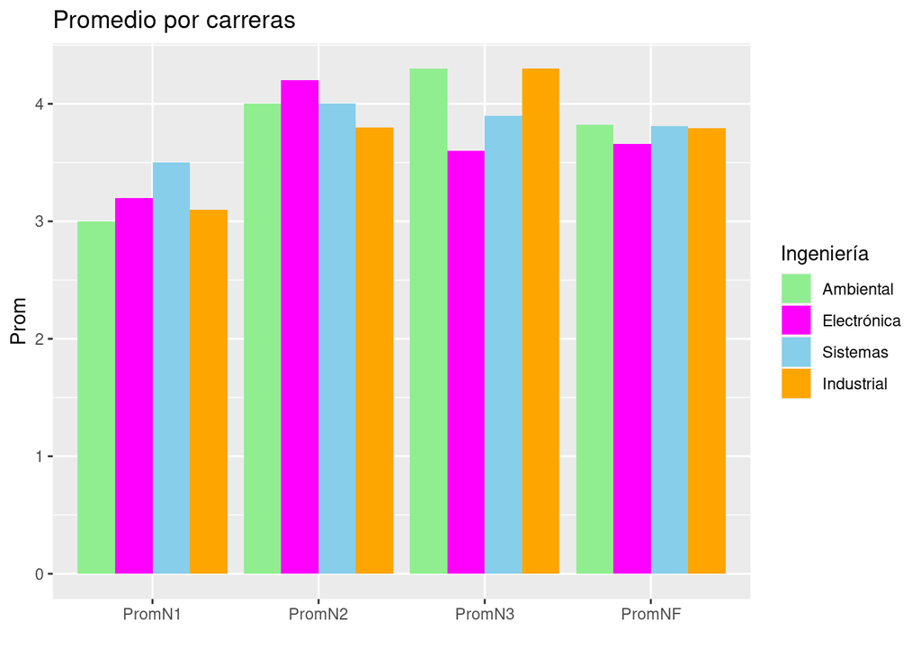

```r
#install.packages(reshape2, dependencies = TRUE)
library(reshape2)
df_plot <- melt(df1, id.vars="Carrera")
##
ggplot(df_plot) %>% +
  aes(x = variable, y = value, fill = as.factor(Carrera)) +
  geom_bar(stat="identity",position="dodge") +
  labs (x = "", y = "Prom", title = "Promedio por carreras") +
  scale_fill_manual(values = c("lightgreen", "  magenta", "skyblue", "orange"), name ="Ingeniería",
                    labels = c("Ambiental", "Electrónica", "Sistemas", "Industrial"))
```